# FUNDAMENTOS DE ANÁLISES DE DADOS

Autor

João Ricardo F. de Lima

Data de Publicação

24 de fevereiro de 2024

# A CIÊNCIA DE DADOS

[^1] O avanço da informática e das telecomunicações possibilitou o armazenamento e a distribuição de conjuntos de dados cada vez mais complexos. Lidar com essas bases de dados exigiu a **sistematização** de diversas técnicas de

- **Coleta e armazenamento**;
- **Tratamento**;
- **Exploração e visualização**;
- **Experimentação e previsão**;
- **Apresentação de dados**.

Essa sistematização promoveu a criação da **Ciência de Dados**, que é basicamente um **conjunto de metodologias** criadas para receber milhares de formatos de dados diferentes que estão disponíveis, com o **objetivo de tirar informações ou conclusões significativas e úteis**.

Os dados podem descrever o **estado atual do conjunto de métricas e indicadores de uma organização**, como por exemplo, o lucro obtido por uma empresa ou o número de clientes ativos em uma plataforma. Essa descrição pode ser resumida em gráficos, painéis interativos (dashboards) ou alertas de mudança de um estado para o outro.

Através dos dados, também é possível diagnosticar as **causas de um evento ou comportamento** de um determinado indicador. Grandes corporações conseguem monitorar as atividades de seus usuários, e consequentemente as mudanças dos seus comportamentos. Também conseguem aplicar mudanças de um aplicativo para determinada amostra de usuários com a finalidade verificar se tal mudança gera maiores benefícios ou interações. Esse último também é aplicável no setor público, através de avaliações de políticas públicas.

Um dos maiores benefícios dos dados está contido também na possibilidade de **prever eventos futuros**. Através de métodos estatísticos e matemáticos, é possível realizar uma estimativa do quanto uma empresa esperar vender ou faturar no mês seguinte, do quanto as instituições esperam do resultado da inflação no próximo mês, ou mesmo, a rotatividade dos usuários em um determinado horizonte de tempo.

Cientistas de dados **criam os projetos de dados** a partir da experimentação; realizam a coleta e limpeza dos dados, analisando-os, construindo previsões e comunicando os resultados.

Portanto, eles necessitam de **habilidades** que os possibilitem performar **todas** essas atividades.

Dependendo da definição e uso dos dados de uma organização, um cientista de dados necessita de uma **qualificação maior em uma área, em detrimento de outra**.

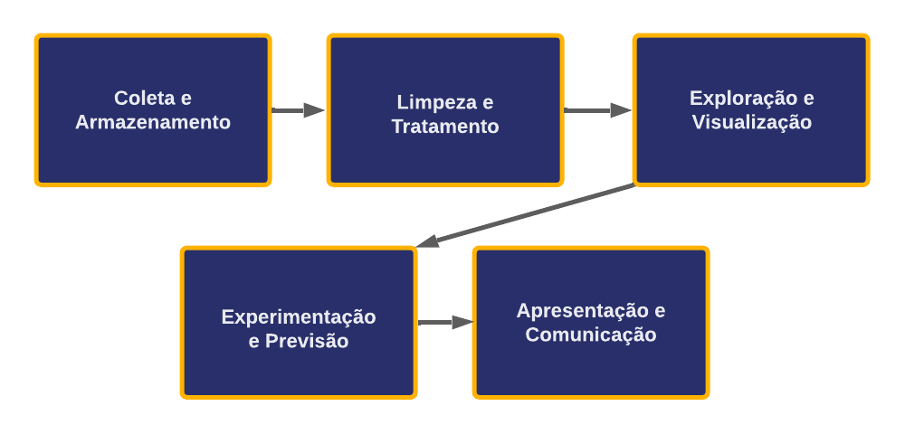

# LINGUAGENS PARA AS CIÊNCIAS DE DADOS

As linguagens de programação são extremamente úteis em todas as etapas acima, criando-se um sistema automatizado permitindo que seja controlado todo o fluxo de dados.

As três linguagens mais utilizadas em Ciência de Dados são: SQL; R; Python.

**SQL** é o acrônimo para **Structured Query Language - Linguagem de Consulta Estruturada** - e é utilizada para acessar, manipular e consultar dados de objetos, ou seja, uma linguagem criada para se comunicar com bancos de dados.

**R** é uma linguagem criada para realizar uma grande variedade de cálculos estatísticos e técnicas para a construção de gráficos.

**Python** é uma linguagem de propósito geral (diferente do R), que possui diversas funcionalidades, entretanto, a partir de bibliotecas criadas pela comunidade, se tornou uma ferramenta poderosa para a análise de dados.

**R e Python são linguagens *open source***. Isso significa que o código base está disponível de graça para qualquer um criar, distribuir ou contribuir com o seu uso. Isso permite que tenha um universo imenso de pacotes grátis criados pela comunidade, que auxiliam na resolução de problemas desde a área de análise geoespacial até para a área de finanças e economia.

[figure not shown]

# O QUE É UM BANCO DE DADOS?

O termo banco de dados (*database*), para a maioria das pessoas, pode significar uma **coleção de dados ou itens** (listas de qualquer tipo, como por exemplo pagamentos mensais, clientes, compras, etc).

Porém, o termo é estritamente definido como uma **coleção de registros integrados que formam um método de coleta e organização de dados**.

E obviamente, implica na utilização de uma tecnologia, como por exemplo:

- planilhas contendo dados de clientes
- arquivos de texto contendo dados sobre voos
- bancos de dados armazenados em nuvem (*Cloud Computing*)
- arquivos de bancos de dados relacionais organizados por SGBDs - Sistema Gerenciador de Bancos de Dados.

## Como funciona um Banco de Dados?

Um **registro** é a representação de um **objeto físico ou conceitual**. Por exemplo, o envio de pedidos para clientes de uma empresa. Cada registro desses pedidos representa um cliente. Os registros possuem **atributos**, como por exemplo, nome, endereço e região. As observações (o registro de cada atributo) são os dados.

Entretanto, os **bancos de dados relacionais** dominam o mercado e são os mais utilizados por sistemas de bancos de dados em empresas.

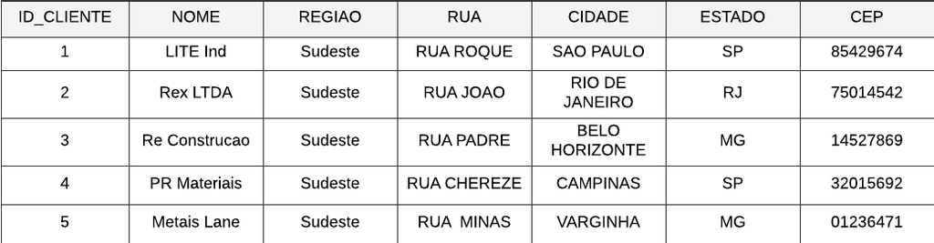

### Formatos dos dados

Os dados podem ser armazenados em diferentes formas e estruturas.

**Não estruturados**, como por exemplo: documentos em texto, imagens e áudios.

**Estruturados**, em formato tabular, como uma planilha ou Data Frame, contendo linhas e colunas.

A maioria dos *softwares* para a análise de dados realiza aplicações em dados estruturados.

Um banco de dados pode possuir **diferentes tamanhos**, de simples coleções de poucos registros para sistemas que possuem milhões. A **usabilidade** do banco de dados pode ser **definida** com base no seu **tamanho**, no **equipamento** em que é utilizado e no **tamanho da organização que o mantém**. Sendo assim, os separamos em três tipos:

- **Banco de dados pessoal**: é desenhado para uma única pessoa para ser utilizado em um único computador. Possui uma estrutura simples e tamanho relativamente pequeno.
- **Banco de dados de uma organização ou grupo de trabalho**: Esse tipo de banco de dados é geralmente maior que um pessoal e mais complexo. Necessita ser utilizado por diversas pessoas que tentam acessar o mesmo dados ao mesmo tempo
- **Banco de dados de uma empresa**: São enormes, guardando informações sobre a organização inteira.

### Sistema gerenciador de banco de dados

Quando se refere a um banco de dados, usualmente está se referindo a um **sistema gerenciador de banco de dados (SGBD)**.

Um SGDB é um **conjunto de programas utilizado para definir, administrar e processar bancos de dados e suas aplicações**. O SGDB é a ferramenta que se utiliza para **construir a estrutura e operacionalizar os dados contidos em um banco de dados**.

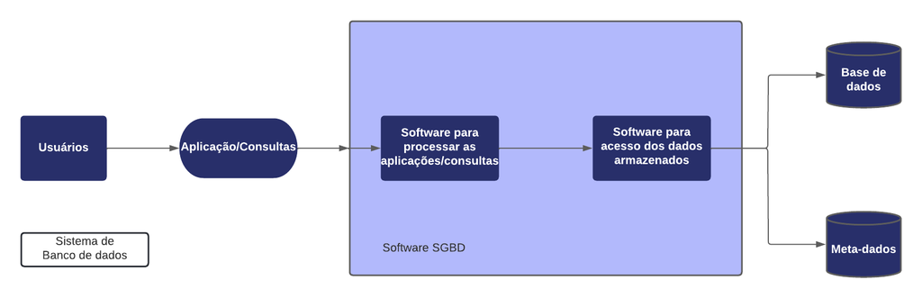

### Bancos de dados Relacionais

Um banco de dados relacional é uma **coleção de tabelas** que se relacionam entre si. Vamos utilizar como exemplo duas tabelas de **PEDIDOS** e **CLIENTES**.

Veja que na primeira tabela, **PEDIDOS**, contém a coluna chamada **ID_CLIENTE**. Essa coluna também está contida na tabela **CLIENTES**. As informações se relacionam de forma que seja possível ligar os dados entre as duas tabelas.

Com isso, através das informações sobre os pedidos, é possível localizar as informações sobre os clientes que realizaram os pedidos.

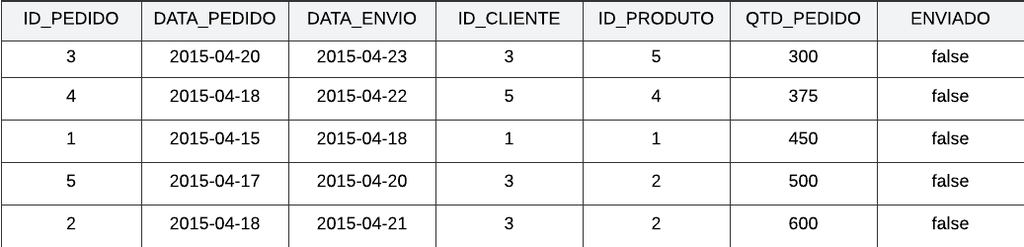

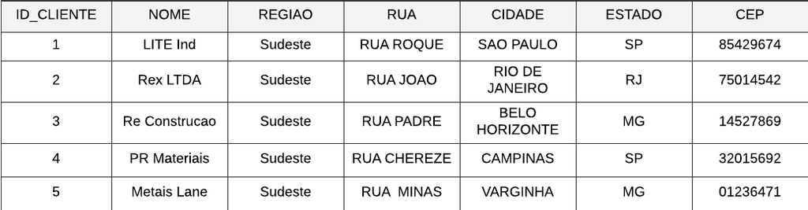

# PARA QUE SERVE A LIMPEZA DE DADOS?

A **limpeza de dados**, também chamada de **tratamento**, envolve todo o processo de **preparar os dados** para que eles sejam utilizados nas fases de exploração, experimentação e previsão.

Os **dados do mundo real são bagunçados e desorganizados**, portanto, sempre teremos problemas em utilizá-los ao coletá-los. Entre os motivos desse problema, tem-se:

- Fontes disponibilizam os dados de forma bagunçada e com erros;
- Dependendo do tipo de arquivo, os dados podem ser disponibilizados desorganizados;
- Métodos de extração ocasionam uma coleta desordenada.

## Estrutura

Idealmente, sempre iremos desejar obter dados estruturados, em formato tabular, em que possuem colunas (representando as variáveis) e linhas (que representam os registros).

Na categoria de dados estruturados, temos dois tipos de formatos: wide e long.

### Wide

O formato wide é conhecido por possuir uma coluna para cada variável, como o abaixo:

| Data | PIB | Inflação | Desemprego |
| --- | --- | --- | --- |
| 2010 | 2 | 4 | 8 |
| 2011 | 2.2 | 5 | 7.6 |

*Dados fictícios

### Long

Já o formato long, “gira” e empilha as variáveis, tornando-as observações, criando uma estrutura concisa em número de colunas, porém, mais longa, repetindo observações.

[output not shown]

*Dados fictícios

## Tipos de dados

Os dados podem ser **categorizados** em diferentes **tipos**, tanto do ponto de vista **computacional**, quanto do **estatístico** (que iremos entender melhor na próxima aula de exploração).

Do ponto de vista da programação, os dados são **reconhecidos** computacionalmente de diferentes formas.

Cada linguagem possui suas **regras de reconhecimento**, entretanto, uma coisa é certa: no processo de coleta, nem sempre a linguagem irá **reconhecer os tipos de dados corretamente**, sendo necessário uma mudanças.

Entre os diferentes tipos de dados comuns, que possuem semelhanças de reconhecimento entre as linguagens de programação, temos

| Nome usual do tipo | O que reconhece |
| --- | --- |
| numeric; double; float | Números reais |
| integer | Números Inteiros |
| strings; character; text | Textos e caracteres |
| booleans; logical | Lógicos (Verdadeiro ou Falso) |
| Date | Data |

Portanto, o **principal desafio** da limpeza será o de **alterar** o reconhecimento dos tipos de dados. Vamos utilizar com exemplo a tabela anterior, entretanto, com algumas alterações:

[output not shown]

*Dados fictícios

Tem-se diversos problemas em relação ao reconhecimento, como:

- Reconhecimento de caractere ao invés de numérico por efeito do símbolo %.
- Problemas em relação a vírgula com decimal e não ponto;
- Caracteres especiais nas palavras, causa problemas com a linguagem de programação;
- As observações da data pode ser reconhecida com inteiro, e não como data.

## Valores nulos

Os valores ausentes são ocasiados por:

- Erros de registro dos dados;
- Erros de coleta;
- O registro realmente não aconteceu

Para lidar com esse valores, existem técnicas de imputação, que permitem realizar aproximações do valor.

Ou mesmo, a exclusão da linha contendo o valor ausente.

E há casos em que não há nenhuma necessidade de realizar mudanças.

| Data | PIB | Inflação | Desemprego |
| --- | --- | --- | --- |
| 2010 | 2 | 4 | 8 |
| 2011 |  | 5 | 7.6 |

*Dados fictícios

# DATA WRANGLING

O processo de limpeza é interligado com o processo de exploração por meio do data wrangling: **manipular os dados de forma que se consiga utilizar as ferramentas de exploração**.

**Data wrangling** é o processo de transformar e manipular dados em formatos “crus” para outro formato com a intenção de entregar as informações contidas no dados em informação útil, sendo o processo necessário para a construção de gráficos, estatísticas descritivas e também para a modelagem. O objetivo do processo é assegurar a qualidade e a usabilidade dos dados.

Existem funções que facilitam o processo de data wrangling, permitindo que a partir de um data frame, o usuário o transforme em um formato útil. As principais funções estão contidas no pacote dplyr, também chamadas de verbs. Alguns verbs uteis são:

- filter() - permite que seja filtrado as linhas/observações de um data frame de acordo com uma condição;
- summarize() - sumariza uma ou mais colunas/variáveis, permitindo calcular uma estatísticas por meio de grupos;
- group_by() - agrupa as linhas de acordo com um mesmo grupo/categorias. É utilizado em conjunto com summarize() de forma que seja possível calcular as estatísticas de um grupo separadamente;
- mutate() - utiliza colunas existentes do data frame para criar novas colunas;
- arrange() - permite ordenar as linhas em ordem ascendente ou descendente;
- recode() - permite alterar o nome das observações de uma coluna;
- select() - seleciona as colunas especificadas (também permite alterar seus nomes).

Os dados em geral não são importados no formato ideal, portanto, sempre é necessário mudanças.

Com o SQL, pode-se utilizar os principais comandos da linguagem para lidar com diversos problemas de limpeza e manipulação de dados.

O Python, com suas funcionalidades e com as bibliotecas NumPy e Pandas, podem lidar facilmente com essas questões.

E o R, tanto com suas funções padrão e com o universo do Tidyverse, conseguem transformar os dados facilmente para a exploração.

```r
library(sidrar)
library(dplyr)


# Pessoas de 14+ anos (Mil pessoas): ocupados/desocupados na Força de trabalho
raw_ocupados_desocupados <- sidrar::get_sidra(api = "/t/6318/n1/all/v/1641/p/all/c629/all")

str(raw_ocupados_desocupados)
```

```
'data.frame':   710 obs. of  13 variables:
 $ Nível Territorial (Código)                                             : chr  "1" "1" "1" "1" ...
 $ Nível Territorial                                                      : chr  "Brasil" "Brasil" "Brasil" "Brasil" ...
 $ Unidade de Medida (Código)                                             : chr  "1572" "1572" "1572" "1572" ...
 $ Unidade de Medida                                                      : chr  "Mil pessoas" "Mil pessoas" "Mil pessoas" "Mil pessoas" ...
 $ Valor                                                                  : num  153601 95664 88011 7653 57937 ...
 $ Brasil (Código)                                                        : chr  "1" "1" "1" "1" ...
 $ Brasil                                                                 : chr  "Brasil" "Brasil" "Brasil" "Brasil" ...
 $ Variável (Código)                                                      : chr  "1641" "1641" "1641" "1641" ...
 $ Variável                                                               : chr  "Pessoas de 14 anos ou mais de idade" "Pessoas de 14 anos ou mais de idade" "Pessoas de 14 anos ou mais de idade" "Pessoas de 14 anos ou mais de idade" ...
 $ Trimestre Móvel (Código)                                               : chr  "201203" "201203" "201203" "201203" ...
 $ Trimestre Móvel                                                        : chr  "jan-fev-mar 2012" "jan-fev-mar 2012" "jan-fev-mar 2012" "jan-fev-mar 2012" ...
 $ Condição em relação à força de trabalho e condição de ocupação (Código): chr  "32385" "32386" "32387" "32446" ...
 $ Condição em relação à força de trabalho e condição de ocupação         : chr  "Total" "Força de trabalho" "Força de trabalho - ocupada" "Força de trabalho - desocupada" ...
```

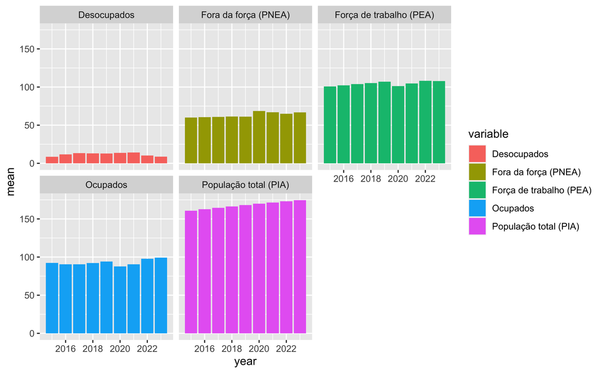

```r
# Pessoas de 14+ anos (Mil pessoas): ocupados/desocupados na Força de trabalho
ocupados_desocupados <- raw_ocupados_desocupados |>
  dplyr::select(
    "date"     = `Trimestre Móvel (Código)`,
    "variable" = `Condição em relação à força de trabalho e condição de ocupação`,
    "value"    = `Valor`
  ) |>
  dplyr::as_tibble()

ocupados_desocupados <- ocupados_desocupados |>
  dplyr::mutate(
    date = lubridate::ym(date),
    variable = dplyr::recode(
      variable,
      "Total"                          = "População total (PIA)",
      "Força de trabalho"              = "Força de trabalho (PEA)",
      "Força de trabalho - ocupada"    = "Ocupados",
      "Força de trabalho - desocupada" = "Desocupados",
      "Fora da força de trabalho"      = "Fora da força (PNEA)"
    ),
    value = value / 1000 # converter em milhões de pessoas
  )


ocupados_desocupados <- ocupados_desocupados |>
                          dplyr::filter(date >= "2015-01-01")

ocupados_desocupados <- ocupados_desocupados |>
                        dplyr::group_by(year = lubridate::year(date), variable) |>
                        dplyr::summarize(mean = mean(value))

library(ggplot2)

ggplot2::ggplot(ocupados_desocupados,
                ggplot2::aes(x = year, y = mean, fill = variable))+
  ggplot2::geom_col()+
  ggplot2::facet_wrap(~variable)
```

Para começar o processo de Data wrangling, usa-se a função select(), selecionando apenas as colunas de interesse, e de quebra, alterando os nomes das colunas para um mais simplificado com o uso do pipe (|>). O seu propósito nesse pedaço de código foi colocar o objeto “raw_ocupados_desocupados” dentro do primeiro argumento da função select().

Também é utilizado para colocar o resultado da função select() dentro da função as_tibble(), este alterando a classe do objeto para tibble.

Em seguida, é alterado o tipo do dado da coluna date, uma vez que o R não a reconheceu adequadamente, e utilizada a função recode() para alterar as observações da coluna variable. Para realizar estas alterações, se usa a função mutate(), renomeando as colunas para o seu mesmo nome (para não criar um nova coluna com formato diferente). Para alterar o tipo da coluna date, utiliza-se a função ym() do pacote {lubridate}. Também divide-se o valor da coluna value por 1000.

Para alterar as linhas do data frame, dada certa condição, utiliza-se a função filter(). No caso, se quer apenas dados após a data de 01-01-2015. Utiliza-se o operador >= para dizer que mantenha os valores a partir da data citada.

Então, pode-se calcular a média de cada ano de acordo com cada categoria do data frame. Para isso, agrupa-se os dados com group_by. O agrupamento é feito transformando as data mensais em ano com a função year do pacote {lubridate} e identificando a coluna variable. Em seguida, a função summarize permite calcular a média da coluna value para esses linhas agrupadas.

O resultado é mostrado com um gráfico feito com o ggplot2, visando verificar o crescimento das variáveis ao longo dos anos.

## Notas de rodapé

[^1]: Todo este material foi retirado de diversas postagens da Análise Macro (www.analisemacro.com.br)